# EWAS of Atopic Dermatitis as part of PACE

Thomas Battram

## Summary of project + methods

This study is examining the association between DNA methylation and childhood eczema (up to around 10 years). Studies used different definitions, and in this report we’re checking whether the “stricter” defintions, most of which require a doctor diagnosis, give similar EWAS results to the more lenient definitions that only include rash symptoms. We split the EWAS into “strict” definitions and “lenient” defintions and meta-analysed each set of EWAS. Then we compared the results (see below).

We only used EWAS of childhood AD for the comparison. As a reminder, here is the general definition of childhood AD - cases: AD by age 10, controls:no AD by age 10

The association of each outcome with DNA methylation was originally explored using logistic regression and 3 models with different covariates, for this analysis we are simply using the fully adjusted model, adjusting for the following covariates:

- sex + batch + maternal_age + maternal_smoking + maternal_SES + gestational_age + cell_type (+ selection_factors) (+ ancestry)

## Results

### Cohorts

Table 1: Cohort summary

| Cohort | N (cases, controls) | prevalence | definition |
| --- | --- | --- | --- |
| **Strict definition cohorts** |  |  |  |
| INMA | 304 (144, 160) | 47.4 | Childhood atopic dermatitis was assessed through questionnaire data at different follow ups: 6 months, 14 months and 7 years. In each follow up, doctor diagnosis of eczema was asked to the parents. Ca… |
| PREDO | 792 (54, 738) | 6.8 | Physician diagnosed atopic dermatitis in the child was reported by the mother at the child mean age of 44.1 (SD 9.3) months. Child sex, maternal smoking during pregnancy (yes, yes, but quit in early p… |
| GOYA | 517 (93, 424) | 18.0 | Childhood AD = A doctor has at some point said that the child has eczema/allergic rash, and this rash has been active within the last twelve months OR The child has had an itchy rash within the last t… |
| Total | 1613 (291, 1322) | 18.0 | NA |
| **Lenient definition cohorts** |  |  |  |
| ALSPAC | 673 (343, 330) | 51 | Early onset Cases = rash count of 2 or more from ages 6 to 30 months Controls = rash count <2 & missing <2 timepoints Set to missing if rash count ==1 & missing 1 timepoint Childhood Cases = rash coun… |
| CHS | 197 (50, 147) | 25 | Eczema questionnaire data was collected at two time points for each participant in the analytic sample. Participants’ parents responded to “has your child ever had eczema?” at baseline and four years … |
| EDEN | 153 (69, 84) | 45 | The children’s families were asked to fill in a detailed questionnaire on their child’s health and characteristics at 1, 2, 3 4, and 5 and 8 years. At each follow-up, eczema was defined as parental-re… |
| GenR | 450 (69, 381) | 15 | Information about eczema in the past 6 months was collected at age 2 years (Has your child had eczema in the last 6 months? [Not as far as I know / Yes, did not go the doctor / Yes, went to the GP / Y… |
| MoBa1 | 828 (398, 430) | 48 | Eczema/Atopic Dermatitis variables were calculated based on questionnaire data. - childhood_ae: case - atopic derm at 6mon, 18mon, 36mon, or 7y; control - no atopic derm at any of these time points - … |
| MoBa2 | 418 (179, 239) | 43 | AD definition for Early onset, by age 3, based on maternal report from the 6, 18 and 36 months of age. AD definition of persistent, no AD by age 7 based on maternal report. |
| VITO | 78 (23, 55) | 29 | Information on eczema (atopic dermatitis) of the children was collected based on the ISAAC questionnaire (5). Children were considered as cases if parents reported a doctor diagnosis for eczema, or if… |
| IOW-F2 | 605 (177, 428) | 29 | Eczema at infancy was determined using the International Study of Asthma and Allergies in Childhood (ISAAC) questionnaire completed by the mothers at three months, six months, and twelve months respec… |
| Total | 3402 (1308, 2094) | 38 | NA |

### Plots

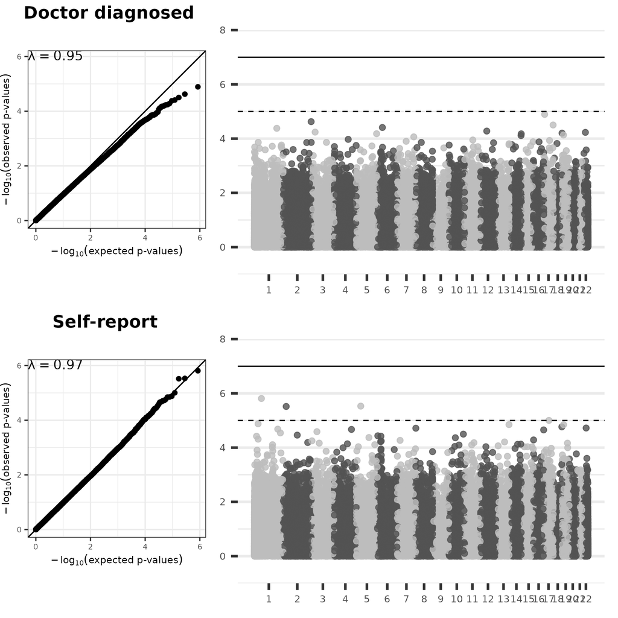

### Results summary

Table 2: Correlation and replication of results

| Metric | Value |
| --- | --- |
| Correlation of all sites | 0.015 |
| Correlation of top 30 strict sites | 0.436 |
| Correlation of top 30 lenient sites | 0.436 |
| Replication of top 30 strict sites | 2.000 |
| Replication of top 30 lenient sites | 0.000 |

Note:  
Correlation means Pearson’s correlation of meta-analysis effect estimates. Top 30 sites = 30 CpG sites with the lowest P value. Replication is assessed at P<0.05.